# Introduction to Neural Networks: Bank Churn prediction

### Model Building: Neural Network model with Adam Optimizer

```python
backend.clear_session()
#Fixing the seed for random number generators so that we can ensure we receive the same output everytime
np.random.seed(2)
random.seed(2)
tf.random.set_seed(2)
```

```python
def create_model():
    # Initializing the neural network
    model = Sequential()

    # Add the input layer with 64 neurons and relu as activation function
    model.add(Dense(64, activation='relu', input_dim=X_train.shape[1]))

    # Add the first hidden layer with 32 neurons with relu as activation function
    model.add(Dense(32, activation='relu'))

    # Add the output layer with Sigmoid Activation
    model.add(Dense(1, activation='sigmoid'))

    # Initialize the model with Adam Optimizer
    optimizer = tf.keras.optimizers.Adam(0.001)

    # Compile the model with binary cross entropy as loss function and accuracy as metrics
    model.compile(loss='binary_crossentropy', optimizer=optimizer, metrics=['accuracy'])
    return model
```

```python
model=create_model()
model.summary()
```

```
Model: "sequential"
_________________________________________________________________
 Layer (type)                Output Shape              Param #
=================================================================
 dense (Dense)               (None, 64)                768

 dense_1 (Dense)             (None, 32)                2080

 dense_2 (Dense)             (None, 1)                 33

=================================================================
Total params: 2,881
Trainable params: 2,881
Non-trainable params: 0
_________________________________________________________________
```

```python
history = model.fit(X_train, y_train, batch_size=32, validation_data=(X_val, y_val), epochs=100, verbose=1)
```

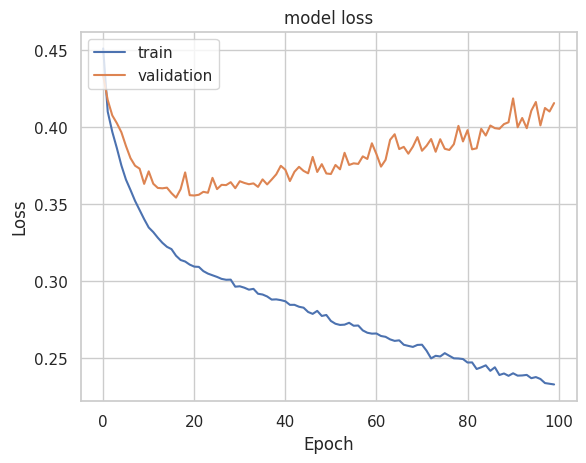

```python
#Plotting Train Loss vs Validation Loss
plt.plot(history.history['loss'])
plt.plot(history.history['val_loss'])
plt.title('model loss')
plt.ylabel('Loss')
plt.xlabel('Epoch')
plt.legend(['train', 'validation'], loc='upper left')
plt.show()
```

```python
# Early stopping
from tensorflow.keras import callbacks

# Importing the EarlyStopping callback
from tensorflow.keras.callbacks import EarlyStopping

# Defining Early stopping
es_cb = EarlyStopping(monitor='val_loss', min_delta=0.001, patience=5)

# Calling the create_model() function to create the model
model_e = create_model()

# Training the model on X_train and y_train for 100 epochs and using X_val and y_val as validation data
history_e = model_e.fit(X_train, y_train, batch_size=32, epochs=100, verbose=1, validation_data=(X_val, y_val), callbacks=[es_cb])
```

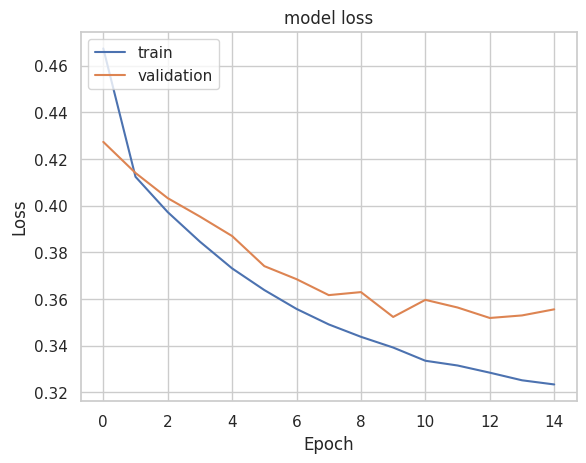

```python
# Loss function
# Plotting Train Loss vs Validation Loss
plt.plot(history_e.history['loss'])
plt.plot(history_e.history['val_loss'])
plt.title('model loss')
plt.ylabel('Loss')
plt.xlabel('Epoch')
plt.legend(['train', 'validation'], loc='upper left')
plt.show()
```

Tune ROC-AUC threshold

```
Best Threshold=0.167119, G-Mean=0.802
```

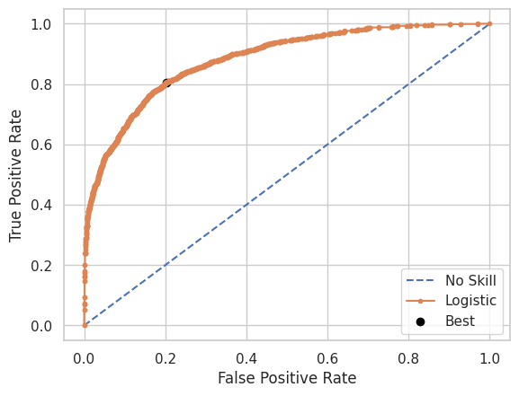

```python
# predict probabilities
yhat = model_e.predict(X_train)
# keep probabilities for the positive outcome only
yhat = yhat[:, 0]
# calculate roc curves
fpr, tpr, thresholds = roc_curve(y_train, yhat)
# calculate the g-mean for each threshold
gmeans = np.sqrt(tpr * (1-fpr))
# locate the index of the largest g-mean
ix = np.argmax(gmeans)
print('Best Threshold=%f, G-Mean=%.3f' % (thresholds[ix], gmeans[ix]))
# plot the roc curve for the model
pyplot.plot([0,1], [0,1], linestyle='--', label='No Skill')
pyplot.plot(fpr, tpr, marker='.', label='Logistic')
pyplot.scatter(fpr[ix], tpr[ix], marker='o', color='black', label='Best')
# axis labels
pyplot.xlabel('False Positive Rate')
pyplot.ylabel('True Positive Rate')
pyplot.legend()
# show the plot
pyplot.show()
```

```python
#Predict the results using the best threshold
y_pred_e=model_e.predict(X_val)
y_pred_e = (y_pred_e > thresholds[ix])
y_pred_e
```

```
array([[ True],
       [False],
       [False],
       ...,
       [False],
       [ True],
       [ True]])
```

```python
# Classification report
cr = metrics.classification_report(y_val, y_pred_e)
print(cr)
```

```
              precision    recall  f1-score   support

           0       0.93      0.78      0.85      1274
           1       0.48      0.77      0.59       326

    accuracy                           0.78      1600
   macro avg       0.70      0.78      0.72      1600
weighted avg       0.84      0.78      0.80      1600
```

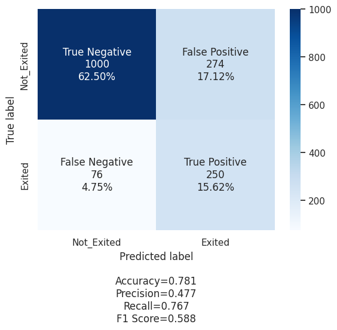

```python
# Confusion Matrix
# Calculate the confusion matrix
cm1 = confusion_matrix(y_val, y_pred_e)
labels = ['True Negative', 'False Positive', 'False Negative', 'True Positive']
categories = ['Not_Exited', 'Exited']

# Generate the confusion matrix plot
make_confusion_matrix(cm1,
                      group_names=labels,
                      categories=categories,
                      cmap='Blues')
```

### Model Improvement: Neural Network model with Dropout

```python
backend.clear_session()
#Fixing the seed for random number generators so that we can ensure we receive the same output everytime
np.random.seed(2)
random.seed(2)
tf.random.set_seed(2)
```

```python
# Initializing the neural network
model_3 = Sequential()

# Adding the input layer with 32 neurons and relu as activation function
model_3.add(Dense(32, activation='relu', input_dim=X_train.shape[1]))

# Adding dropout with dropout_rate= 0.2
model_3.add(Dropout(0.2))

# Adding the first hidden layer with 16 neurons with relu as activation function
model_3.add(Dense(16, activation='relu'))

# Adding dropout with dropout_rate= 0.1
model_3.add(Dropout(0.1))

# Adding the second hidden layer with 8 neurons with relu as activation function
model_3.add(Dense(8, activation='relu'))

# Adding the output layer
model_3.add(Dense(1, activation='sigmoid'))
```

```python
# Summary of the model
model_3.summary()
```

```
Model: "sequential"
_________________________________________________________________
 Layer (type)                Output Shape              Param #
=================================================================
 dense (Dense)               (None, 32)                384

 dropout (Dropout)           (None, 32)                0

 dense_1 (Dense)             (None, 16)                528

 dropout_1 (Dropout)         (None, 16)                0

 dense_2 (Dense)             (None, 8)                 136

 dense_3 (Dense)             (None, 1)                 9

=================================================================
Total params: 1,057
Trainable params: 1,057
Non-trainable params: 0
_________________________________________________________________
```

```python
# Initialize the ANN with Adam optimizer
optimizer = tf.keras.optimizers.Adam(0.001)

model_3.compile(loss='binary_crossentropy', optimizer=optimizer, metrics=['accuracy'])
```

```python
#Fitting the ANN with batch_size = 32 and 100 epochs
history_3 = model_3.fit(X_train,y_train,batch_size=32,epochs=100,verbose=1,validation_data=(X_val,y_val),callbacks=[es_cb])
```

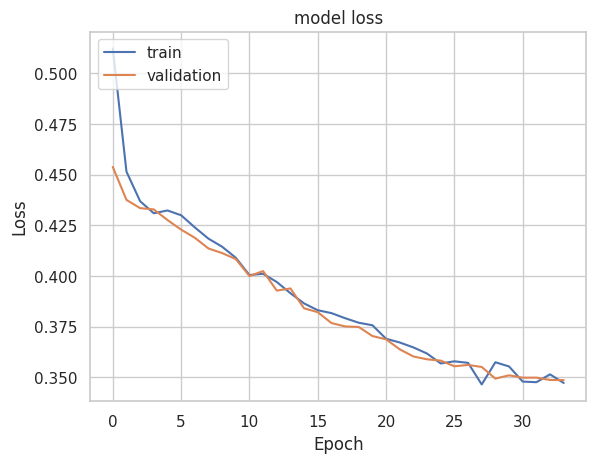

```python
# Loss function
plt.plot(history_3.history['loss'])
plt.plot(history_3.history['val_loss'])
plt.title('model loss')
plt.ylabel('Loss')
plt.xlabel('Epoch')
plt.legend(['train', 'validation'], loc='upper left')
plt.show()
```

```
Best Threshold=0.220600, G-Mean=0.793
```

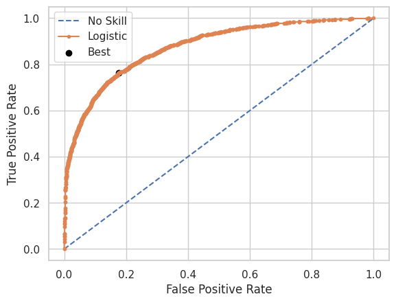

```python
# predict probabilities
yhat = model_3.predict(X_train)
# keep probabilities for the positive outcome only
yhat = yhat[:, 0]
# calculate roc curves
fpr, tpr, thresholds = roc_curve(y_train, yhat)
# calculate the g-mean for each threshold
gmeans = np.sqrt(tpr * (1-fpr))
# locate the index of the largest g-mean
ix = np.argmax(gmeans)
print('Best Threshold=%f, G-Mean=%.3f' % (thresholds[ix], gmeans[ix]))
# plot the roc curve for the model
pyplot.plot([0,1], [0,1], linestyle='--', label='No Skill')
pyplot.plot(fpr, tpr, marker='.', label='Logistic')
pyplot.scatter(fpr[ix], tpr[ix], marker='o', color='black', label='Best')
# axis labels
pyplot.xlabel('False Positive Rate')
pyplot.ylabel('True Positive Rate')
pyplot.legend()
# show the plot
pyplot.show()
```

```python
#Predicting the results using best as a threshold
y_pred_e=model_3.predict(X_val)
y_pred_3 = (y_pred_e > thresholds[ix])
y_pred_3
```

```
array([[False],
       [False],
       [False],
       ...,
       [False],
       [ True],
       [ True]])
```

```python
# Classification report
cr = metrics.classification_report(y_val, y_pred_3)
print(cr)
```

```
              precision    recall  f1-score   support

           0       0.93      0.82      0.87      1274
           1       0.51      0.75      0.61       326

    accuracy                           0.81      1600
   macro avg       0.72      0.78      0.74      1600
weighted avg       0.84      0.81      0.82      1600
```

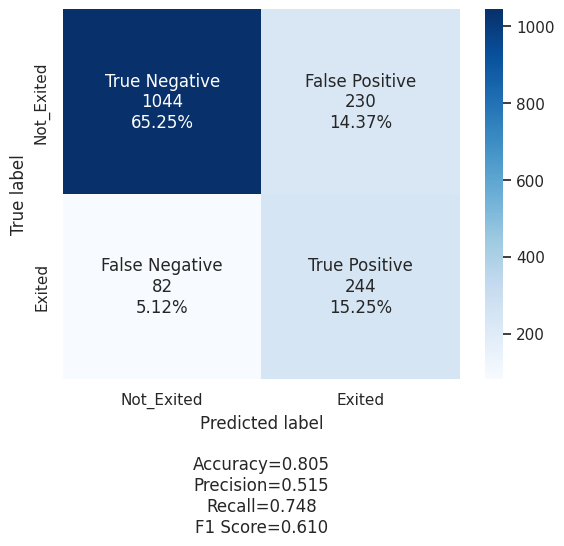

```python
# Confusion report
cm1 = confusion_matrix(y_val, y_pred_3)
labels = ['True Negative', 'False Positive', 'False Negative', 'True Positive']
categories = ['Not_Exited', 'Exited']
make_confusion_matrix(cm1,
                      group_names=labels,
                      categories=categories,
                      cmap='Blues')
```

### Model Improvement: Neural Network model with Hyperparameter tuning

```python
backend.clear_session()
#Fixing the seed for random number generators so that we can ensure we receive the same output everytime
np.random.seed(2)
random.seed(2)
tf.random.set_seed(2)
```

```python
def create_model_v2(dropout_rate=0.1, lr=0.001, layer_1=64, layer_2=32):
    np.random.seed(1337)

    # Initializing the neural network
    model = Sequential()

    # Adding the input layer (by specifying input dimension)
    model.add(Dense(layer_1, activation='relu', input_dim=X_train.shape[1]))

    # Adding dropout with specified dropout rate
    model.add(Dropout(dropout_rate))

    # Adding the hidden layer
    model.add(Dense(layer_2, activation='relu'))

    # Adding the output layer
    model.add(Dense(1, activation='sigmoid'))

    # Adding Adam optimizer with specified learning rate
    optimizer = tf.keras.optimizers.Adam(learning_rate=lr)

    # Compiling the model using binary_crossentropy as loss
    model.compile(optimizer=optimizer, loss='binary_crossentropy', metrics=['accuracy'])
    return model
```

```python
def model_wrapper(dropout_rate=0.1, lr=0.001, layer_1=64, layer_2=32):
    return create_model_v2(dropout_rate, lr, layer_1, layer_2)



# Use Grid saerch
keras_estimator = KerasClassifier(build_fn=create_model_v2, dropout_rate=0.1, lr=0.001, layer_1=64, layer_2=32, verbose=1)
```

```python
# Define the grid search parameters
param_grid = {
    'dropout_rate': [0.1, 0.2, 0.3],
    'lr': [0.01, 0.001, 0.1],
    'layer_1': [32, 64],
    'layer_2': [16, 32],
    'batch_size': [40, 64, 128]
}

kfold_splits = 3


# Using the defined keras_estimator as the estimator in GridSearchCV
grid = GridSearchCV(estimator=keras_estimator, param_grid=param_grid, cv=kfold_splits, verbose=1, n_jobs=-1)
```

```python
grid_result = grid.fit(X_train, y_train, validation_data=(X_val, y_val), verbose=1)

# Summarize results
print("Best: %f using %s" % (grid_result.best_score_, grid_result.best_params_))

# Printing mean test scores, standard deviations, and parameters
means = grid_result.cv_results_['mean_test_score']
stds = grid_result.cv_results_['std_test_score']
params = grid_result.cv_results_['params']
for mean, stdev, param in zip(means, stds, params):
    print("%f (%f) with: %r" % (mean, stdev, param))
```

```
Fitting 3 folds for each of 108 candidates, totalling 324 fits
Best: 0.825781 using {'batch_size': 40, 'dropout_rate': 0.1, 'layer_1': 64, 'layer_2': 32, 'lr': 0.01}
0.817969 (0.004294) with: {'batch_size': 40, 'dropout_rate': 0.1, 'layer_1': 32, 'layer_2': 16, 'lr': 0.01}
0.796250 (0.000202) with: {'batch_size': 40, 'dropout_rate': 0.1, 'layer_1': 32, 'layer_2': 16, 'lr': 0.001}
0.796406 (0.000176) with: {'batch_size': 40, 'dropout_rate': 0.1, 'layer_1': 32, 'layer_2': 16, 'lr': 0.1}
0.818281 (0.003011) with: {'batch_size': 40, 'dropout_rate': 0.1, 'layer_1': 32, 'layer_2': 32, 'lr': 0.01}
0.796875 (0.000421) with: {'batch_size': 40, 'dropout_rate': 0.1, 'layer_1': 32, 'layer_2': 32, 'lr': 0.001}
0.810624 (0.010219) with: {'batch_size': 40, 'dropout_rate': 0.1, 'layer_1': 32, 'layer_2': 32, 'lr': 0.1}
0.817813 (0.003468) with: {'batch_size': 40, 'dropout_rate': 0.1, 'layer_1': 64, 'layer_2': 16, 'lr': 0.01}
0.797657 (0.001885) with: {'batch_size': 40, 'dropout_rate': 0.1, 'layer_1': 64, 'layer_2': 16, 'lr': 0.001}
0.802501 (0.009039) with: {'batch_size': 40, 'dropout_rate': 0.1, 'layer_1': 64, 'layer_2': 16, 'lr': 0.1}
0.825781 (0.003469) with: {'batch_size': 40, 'dropout_rate': 0.1, 'layer_1': 64, 'layer_2': 32, 'lr': 0.01}
0.802501 (0.003525) with: {'batch_size': 40, 'dropout_rate': 0.1, 'layer_1': 64, 'layer_2': 32, 'lr': 0.001}
0.796250 (0.000202) with: {'batch_size': 40, 'dropout_rate': 0.1, 'layer_1': 64, 'layer_2': 32, 'lr': 0.1}
0.808751 (0.005946) with: {'batch_size': 40, 'dropout_rate': 0.2, 'layer_1': 32, 'layer_2': 16, 'lr': 0.01}
0.796250 (0.000466) with: {'batch_size': 40, 'dropout_rate': 0.2, 'layer_1': 32, 'layer_2': 16, 'lr': 0.001}
0.796250 (0.000202) with: {'batch_size': 40, 'dropout_rate': 0.2, 'layer_1': 32, 'layer_2': 16, 'lr': 0.1}
0.810935 (0.012697) with: {'batch_size': 40, 'dropout_rate': 0.2, 'layer_1': 32, 'layer_2': 32, 'lr': 0.01}
0.797499 (0.002723) with: {'batch_size': 40, 'dropout_rate': 0.2, 'layer_1': 32, 'layer_2': 32, 'lr': 0.001}
0.797813 (0.005299) with: {'batch_size': 40, 'dropout_rate': 0.2, 'layer_1': 32, 'layer_2': 32, 'lr': 0.1}
0.815938 (0.005267) with: {'batch_size': 40, 'dropout_rate': 0.2, 'layer_1': 64, 'layer_2': 16, 'lr': 0.01}
0.801720 (0.004097) with: {'batch_size': 40, 'dropout_rate': 0.2, 'layer_1': 64, 'layer_2': 16, 'lr': 0.001}
0.806875 (0.009427) with: {'batch_size': 40, 'dropout_rate': 0.2, 'layer_1': 64, 'layer_2': 16, 'lr': 0.1}
0.822031 (0.004143) with: {'batch_size': 40, 'dropout_rate': 0.2, 'layer_1': 64, 'layer_2': 32, 'lr': 0.01}
0.803437 (0.002232) with: {'batch_size': 40, 'dropout_rate': 0.2, 'layer_1': 64, 'layer_2': 32, 'lr': 0.001}
0.796250 (0.000202) with: {'batch_size': 40, 'dropout_rate': 0.2, 'layer_1': 64, 'layer_2': 32, 'lr': 0.1}
0.817187 (0.010285) with: {'batch_size': 40, 'dropout_rate': 0.3, 'layer_1': 32, 'layer_2': 16, 'lr': 0.01}
0.801095 (0.007050) with: {'batch_size': 40, 'dropout_rate': 0.3, 'layer_1': 32, 'layer_2': 16, 'lr': 0.001}
0.799844 (0.005282) with: {'batch_size': 40, 'dropout_rate': 0.3, 'layer_1': 32, 'layer_2': 16, 'lr': 0.1}
0.820781 (0.002268) with: {'batch_size': 40, 'dropout_rate': 0.3, 'layer_1': 32, 'layer_2': 32, 'lr': 0.01}
0.796875 (0.000766) with: {'batch_size': 40, 'dropout_rate': 0.3, 'layer_1': 32, 'layer_2': 32, 'lr': 0.001}
0.792656 (0.005218) with: {'batch_size': 40, 'dropout_rate': 0.3, 'layer_1': 32, 'layer_2': 32, 'lr': 0.1}
0.814842 (0.012986) with: {'batch_size': 40, 'dropout_rate': 0.3, 'layer_1': 64, 'layer_2': 16, 'lr': 0.01}
0.797031 (0.001304) with: {'batch_size': 40, 'dropout_rate': 0.3, 'layer_1': 64, 'layer_2': 16, 'lr': 0.001}
0.796250 (0.000202) with: {'batch_size': 40, 'dropout_rate': 0.3, 'layer_1': 64, 'layer_2': 16, 'lr': 0.1}
0.812344 (0.004413) with: {'batch_size': 40, 'dropout_rate': 0.3, 'layer_1': 64, 'layer_2': 32, 'lr': 0.01}
0.804532 (0.001713) with: {'batch_size': 40, 'dropout_rate': 0.3, 'layer_1': 64, 'layer_2': 32, 'lr': 0.001}
0.802969 (0.006858) with: {'batch_size': 40, 'dropout_rate': 0.3, 'layer_1': 64, 'layer_2': 32, 'lr': 0.1}
0.811877 (0.007626) with: {'batch_size': 64, 'dropout_rate': 0.1, 'layer_1': 32, 'layer_2': 16, 'lr': 0.01}
0.796406 (0.000247) with: {'batch_size': 64, 'dropout_rate': 0.1, 'layer_1': 32, 'layer_2': 16, 'lr': 0.001}
```

[output cut: 55 more lines]

```
0.813438 (0.003633) with: {'batch_size': 128, 'dropout_rate': 0.2, 'layer_1': 64, 'layer_2': 32, 'lr': 0.01}
0.796406 (0.000247) with: {'batch_size': 128, 'dropout_rate': 0.2, 'layer_1': 64, 'layer_2': 32, 'lr': 0.001}
0.797500 (0.000345) with: {'batch_size': 128, 'dropout_rate': 0.2, 'layer_1': 64, 'layer_2': 32, 'lr': 0.1}
0.800469 (0.001563) with: {'batch_size': 128, 'dropout_rate': 0.3, 'layer_1': 32, 'layer_2': 16, 'lr': 0.01}
0.795156 (0.000727) with: {'batch_size': 128, 'dropout_rate': 0.3, 'layer_1': 32, 'layer_2': 16, 'lr': 0.001}
0.796094 (0.000385) with: {'batch_size': 128, 'dropout_rate': 0.3, 'layer_1': 32, 'layer_2': 16, 'lr': 0.1}
0.799219 (0.004411) with: {'batch_size': 128, 'dropout_rate': 0.3, 'layer_1': 32, 'layer_2': 32, 'lr': 0.01}
0.796250 (0.000202) with: {'batch_size': 128, 'dropout_rate': 0.3, 'layer_1': 32, 'layer_2': 32, 'lr': 0.001}
0.799375 (0.003978) with: {'batch_size': 128, 'dropout_rate': 0.3, 'layer_1': 32, 'layer_2': 32, 'lr': 0.1}
0.802500 (0.004221) with: {'batch_size': 128, 'dropout_rate': 0.3, 'layer_1': 64, 'layer_2': 16, 'lr': 0.01}
0.796250 (0.000202) with: {'batch_size': 128, 'dropout_rate': 0.3, 'layer_1': 64, 'layer_2': 16, 'lr': 0.001}
0.800936 (0.006242) with: {'batch_size': 128, 'dropout_rate': 0.3, 'layer_1': 64, 'layer_2': 16, 'lr': 0.1}
0.818907 (0.003037) with: {'batch_size': 128, 'dropout_rate': 0.3, 'layer_1': 64, 'layer_2': 32, 'lr': 0.01}
0.796250 (0.000202) with: {'batch_size': 128, 'dropout_rate': 0.3, 'layer_1': 64, 'layer_2': 32, 'lr': 0.001}
0.795000 (0.000247) with: {'batch_size': 128, 'dropout_rate': 0.3, 'layer_1': 64, 'layer_2': 32, 'lr': 0.1}
```

Create final model with config post hyperparam tuning

```python
# Creating the model
estimator_v2=create_model_v2(lr=grid_result.best_params_['lr'])
# Printing model summary
estimator_v2.summary()
```

```
Model: "sequential_1"
_________________________________________________________________
 Layer (type)                Output Shape              Param #
=================================================================
 dense_3 (Dense)             (None, 64)                768

 dropout_1 (Dropout)         (None, 64)                0

 dense_4 (Dense)             (None, 32)                2080

 dense_5 (Dense)             (None, 1)                 33

=================================================================
Total params: 2,881
Trainable params: 2,881
Non-trainable params: 0
_________________________________________________________________
```

```python
history_h = estimator_v2.fit(X_train, y_train, epochs=100, batch_size=grid_result.best_params_['batch_size'], verbose=1, validation_data=(X_val, y_val))
```

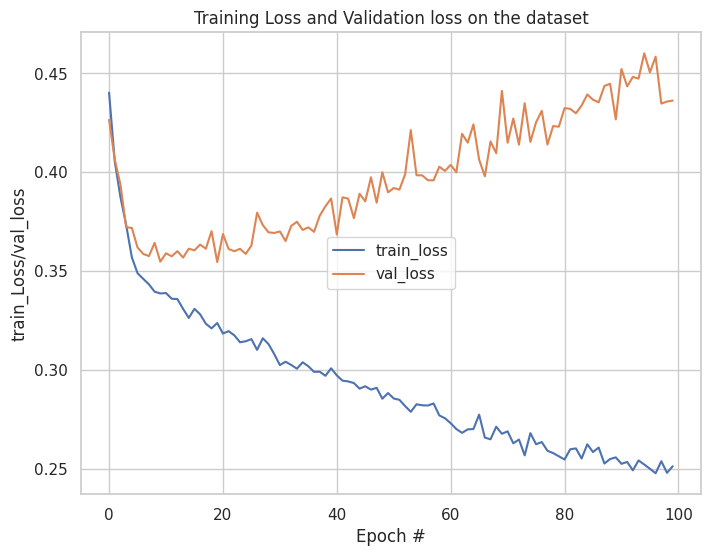

```python
# Loss Function

N =100
plt.figure(figsize=(8,6))
plt.plot(np.arange(0, N), history_h.history["loss"], label="train_loss")
plt.plot(np.arange(0, N), history_h.history["val_loss"], label="val_loss")

plt.title("Training Loss and Validation loss on the dataset")
plt.xlabel("Epoch #")
plt.ylabel("train_Loss/val_loss")
plt.legend(loc="center")
plt.show()
```

```
Best Threshold=0.271687, G-Mean=0.878
```

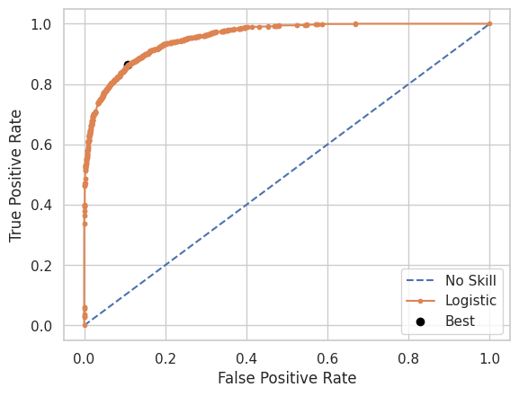

```python
#Threshold
# predict probabilities
yhat = estimator_v2.predict(X_train)
# keep probabilities for the positive outcome only
yhat = yhat[:, 0]
# calculate roc curves
fpr, tpr, thresholds = roc_curve(y_train, yhat)
# calculate the g-mean for each threshold
gmeans = np.sqrt(tpr * (1-fpr))
# locate the index of the largest g-mean
ix = np.argmax(gmeans)
print('Best Threshold=%f, G-Mean=%.3f' % (thresholds[ix], gmeans[ix]))
# plot the roc curve for the model
pyplot.plot([0,1], [0,1], linestyle='--', label='No Skill')
pyplot.plot(fpr, tpr, marker='.', label='Logistic')
pyplot.scatter(fpr[ix], tpr[ix], marker='o', color='black', label='Best')
# axis labels
pyplot.xlabel('False Positive Rate')
pyplot.ylabel('True Positive Rate')
pyplot.legend()
# show the plot
pyplot.show()
```

```python
y_pred_h = estimator_v2.predict(X_val)
print(y_pred_h)
```

```
[[4.7810037e-02]
 [5.8797240e-04]
 [1.0808803e-03]
 ...
 [1.0193800e-01]
 [4.8802760e-01]
 [9.1019893e-01]]
```

```python
# To use the confusion Matrix, we need to convert the probabilities that a customer will leave the bank into the form true or false.
# So we will use the best cutoff value  to indicate whether they are likely to exit or not.
y_pred_h = (y_pred_h > thresholds[ix])
print(y_pred_h)
```

```
[[False]
 [False]
 [False]
 ...
 [False]
 [ True]
 [ True]]
```

```python
# Classification report
cr = metrics.classification_report(y_val, y_pred_h.round())
print(cr)
```

```
              precision    recall  f1-score   support

           0       0.91      0.85      0.88      1274
           1       0.53      0.66      0.59       326

    accuracy                           0.81      1600
   macro avg       0.72      0.75      0.73      1600
weighted avg       0.83      0.81      0.82      1600
```

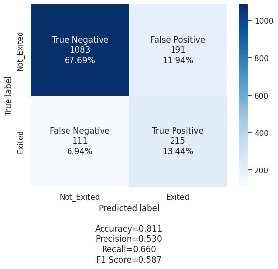

```python
# Confusion Report
cm_h = confusion_matrix(y_val, y_pred_h.round())

labels = ['True Negative', 'False Positive', 'False Negative', 'True Positive']
categories = ['Not_Exited', 'Exited']
make_confusion_matrix(cm_h,
                      group_names=labels,
                      categories=categories,
                      cmap='Blues')
```

```python
# Initialize SMOTE
sm = SMOTE(random_state=42)

# Apply SMOTE on the training data
X_train_smote, y_train_smote = sm.fit_resample(X_train, y_train)

print('After UpSampling, the shape of train_X: {}'.format(X_train_smote.shape))
print('After UpSampling, the shape of train_y: {} \n'.format(y_train_smote.shape))
```

```
After UpSampling, the shape of train_X: (10192, 11)
After UpSampling, the shape of train_y: (10192, 1)
```

[figure not shown]

```python
sns.countplot(y_train['Exited'])
```

```python
#Build a model with the balanced dataset

backend.clear_session()
#Fixing the seed for random number generators so that we can ensure we receive the same output everytime
np.random.seed(2)
random.seed(2)
tf.random.set_seed(2)
```

```python
# Initialize a Sequential model
model_4 = Sequential()

# Add an input layer of 32 neurons with relu activation function
model_4.add(Dense(32, activation='relu', input_dim=X_train.shape[1]))

# Add dropout with dropout rate=0.2
model_4.add(Dropout(0.2))

# Add a hidden layer with 16 neurons with relu activation function
model_4.add(Dense(16, activation='relu'))

# Add dropout
model_4.add(Dropout(0.1))

# Add a dense layer with 8 neurons
model_4.add(Dense(8, activation='relu'))

# Add the output layer with suitable activation function (sigmoid for binary classification)
model_4.add(Dense(1, activation='sigmoid'))
```

```python
# Obtain the summary of the model
model_4.summary()
```

```
Model: "sequential"
_________________________________________________________________
 Layer (type)                Output Shape              Param #
=================================================================
 dense (Dense)               (None, 32)                384

 dropout (Dropout)           (None, 32)                0

 dense_1 (Dense)             (None, 16)                528

 dropout_1 (Dropout)         (None, 16)                0

 dense_2 (Dense)             (None, 8)                 136

 dense_3 (Dense)             (None, 1)                 9

=================================================================
Total params: 1,057
Trainable params: 1,057
Non-trainable params: 0
_________________________________________________________________
```

```python
# Define early stopping as callback
es_cb = callbacks.EarlyStopping(monitor='val_loss', min_delta=0.001, patience=5)

# Initializing Adam optimizer
optimizer = tf.keras.optimizers.Adam(0.001)

# Compiling the model with binary cross entropy as loss and accuracy as metrics
model_4.compile(optimizer=optimizer, loss='binary_crossentropy', metrics=['accuracy'])

# Fit the model on train data with batch_size of 64, epochs of 100 and callbacks as early stopping
history_4 = model_4.fit(X_train, y_train, batch_size=64, epochs=100, verbose=1, validation_data=(X_val, y_val), callbacks=[es_cb])
```

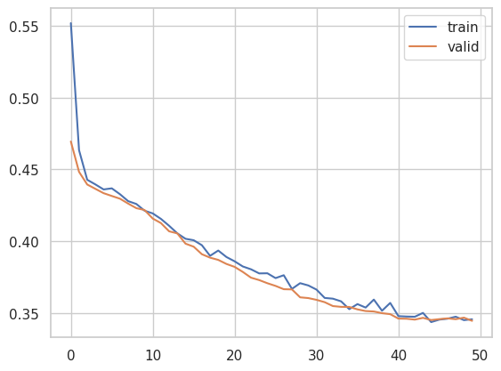

```python
# Loss Function
# Capturing learning history per epoch
hist  = pd.DataFrame(history_4.history)
hist['epoch'] = history_4.epoch

# Plotting accuracy at different epochs
plt.plot(hist['loss'])
plt.plot(hist['val_loss'])
plt.legend(("train" , "valid") , loc =0)
```

```
Best Threshold=0.225649, G-Mean=0.791
```

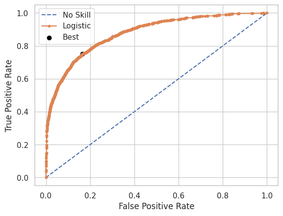

```python
# Finding optimal threshold
# Finding the optimal threshold using X_train
yhat = model_4.predict(X_train)

# Keep probabilities for the positive outcome only
yhat = yhat[:, 0]
# Calculate ROC curves
fpr, tpr, thresholds = roc_curve(y_train, yhat)
# Calculate the G-mean for each threshold
gmeans = np.sqrt(tpr * (1-fpr))
# Locate the index of the largest G-mean
ix = np.argmax(gmeans)
print('Best Threshold=%f, G-Mean=%.3f' % (thresholds[ix], gmeans[ix]))

# Plot the ROC curve for the model
pyplot.plot([0,1], [0,1], linestyle='--', label='No Skill')
pyplot.plot(fpr, tpr, marker='.', label='Logistic')
pyplot.scatter(fpr[ix], tpr[ix], marker='o', color='black', label='Best')
# Axis labels
pyplot.xlabel('False Positive Rate')
pyplot.ylabel('True Positive Rate')
pyplot.legend()
# Show the plot
pyplot.show()
```

```python
# Obtain the predictions on X_val
y_pred_s = model_4.predict(X_val)
# Predicting the results using the tuned threshold
y_pred_s = (y_pred_s > thresholds[ix])
```

```python
# Classification report
cr=metrics.classification_report(y_val,y_pred_s)
print(cr)
```

```
              precision    recall  f1-score   support

           0       0.92      0.83      0.87      1274
           1       0.52      0.74      0.61       326

    accuracy                           0.81      1600
   macro avg       0.72      0.78      0.74      1600
weighted avg       0.84      0.81      0.82      1600
```

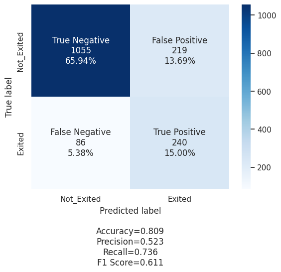

```python
#Calculating the confusion matrix
cm_s=confusion_matrix(y_val, y_pred_s)
labels = ['True Negative','False Positive','False Negative','True Positive']
categories = [ 'Not_Exited','Exited']
make_confusion_matrix(cm_s,
                      group_names=labels,
                      categories=categories,
                      cmap='Blues')
```

## Final Model

```
Best Threshold=0.167119, G-Mean=0.802
```

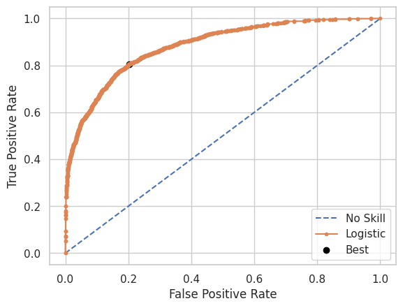

```python
# Predict probabilities using the best model (assuming model_4 is the best model)
yhat = model_e.predict(X_train)

# Keep probabilities for the positive outcome only
yhat = yhat[:, 0]

# Calculate ROC curves
fpr, tpr, thresholds = roc_curve(y_train, yhat)

# Calculate the G-mean for each threshold
gmeans = np.sqrt(tpr * (1-fpr))

# Locate the index of the largest G-mean
ix = np.argmax(gmeans)
print('Best Threshold=%f, G-Mean=%.3f' % (thresholds[ix], gmeans[ix]))

# Plot the ROC curve for the model
pyplot.plot([0,1], [0,1], linestyle='--', label='No Skill')
pyplot.plot(fpr, tpr, marker='.', label='Logistic')
pyplot.scatter(fpr[ix], tpr[ix], marker='o', color='black', label='Best')

# Axis labels
pyplot.xlabel('False Positive Rate')
pyplot.ylabel('True Positive Rate')
pyplot.legend()

# Show the plot
pyplot.show()
```

```python
y_pred_test = model_3.predict(X_test)
y_pred_test = (y_pred_test > thresholds[ix])
print(y_pred_test)
```

```
[[False]
 [False]
 [False]
 ...
 [ True]
 [False]
 [False]]
```

```python
 cr = metrics.classification_report(y_test, y_pred_test)
print(cr)
```

```
              precision    recall  f1-score   support

           0       0.94      0.71      0.81      1593
           1       0.42      0.84      0.56       407

    accuracy                           0.73      2000
   macro avg       0.68      0.77      0.68      2000
weighted avg       0.84      0.73      0.76      2000
```

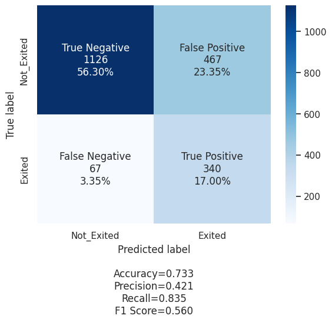

```python
# Confusion Report
cm_h = confusion_matrix(y_test, y_pred_test)

labels = ['True Negative', 'False Positive', 'False Negative', 'True Positive']
categories = ['Not_Exited', 'Exited']
make_confusion_matrix(cm_h,
                      group_names=labels,
                      categories=categories,
                      cmap='Blues')
```

## Actionable Insights and Recommendations

**What recommedations would you suggest to the bank?**

- Focus on Older Customers: Implement targeted retention strategies for older customers.
- Review Product Offerings: Analyze why customers with fewer products are more likely to churn. Consider offering incentives for using multiple products.
- Engagement with Inactive Members: Develop programs to increase engagement among inactive members.
- Geographic Focus: Investigate why customers in Germany are more prone to churn and adapt strategies accordingly.

Model Reccomendations:

- Adam Optimizer
- Neural Network model with Dropout
- Recall of about 83%
- In our specific case, a recall of 83% means that our model correctly identified 83% of all the customers who left the bank. For every 100 customers who churned, our model successfully flagged 83 of them as potential churn risks.
- This is significant for our churn prevention strategies. With this model, we can proactively identify a large portion of at-risk customers. It allows us to intervene early, perhaps with personalized offers or improved services, to retain them.
- However, it's also important to note that 17% of customers who ended up leaving weren't flagged by our model. These cases represent opportunities for further improvement in our predictive capabilities and understanding of customer behavior.
- While a high recall is beneficial, it's part of a broader picture. We also need to consider other factors like precision (how many of the customers we identified as at-risk actually left) to ensure a balanced approach. Focusing solely on recall might lead us to flag too many customers as at-risk, including many who wouldn't have left, potentially leading to unnecessary or misdirected efforts.
- We can use these insights to refine our models further and also to tailor our customer retention strategies. Understanding why certain customers are more likely to leave helps us address their specific needs and concerns more effectively.
- Executive Summary: A 83% recall is a strong starting point for identifying at-risk customers, but it should be viewed as part of a larger strategy that balances accuracy, customer experience, and operational efficiency.